# Short tutorial on igraph package in R

## Introduction

This is a short tutorial for the package `igraph`.

It contains basic commands for loading network data, analyzing and plotting the network.  
At the end of this tutorial you should be able to:  
1. Load network data into R  
2. Perform a simple analysis of the network  
3. Visualize the network  
4. Compute centrality indicators  
5. Compute indicators of social capital and structural holes

## Preliminaries

When you start the analysis it is good habit to clean the memory. This is accomplished with the command `rm` (which stands for remove)

```r
## clear memory
rm(list=ls())
```

The code removes all the variables in the memory. Next we set up our working directory with `setwd`. The command tells R where to look for files and where to save the output. You should change the actual directory to a directory that exists in your computer, of course.

```r
## set working directory to your directory
## in windows
#setwd("C:/Users/amele1/Dropbox/networkminicourse/codes/")
## in mac
#setwd("/Users/Angelo/Dropbox/NetOrgJHU/GMBA_fall2016/Rtutorials")
#setwd("/Users/Angelo_1/Dropbox/networkminicourse/codes/")
```

To perform the network analysis we need to use an R library called `igraph`. This library allows us to load network data, and to compute several statistics of the network.  
If you have not installed the package yet, you can install it with

```
# install package igraph (if you haven't already)
install.packages("igraph", dependencies=TRUE, repos="http://lib.stat.cmu.edu/R/CRAN/")
```

Once `igraph` is installed, we load the library with

```r
## load the igraph package
library(igraph)
```

For this example, we will use the network of florentine families discussed in class. It contains 15 of the most important families in the Rennaissance. The network corresponds to the marriages among families. The data are contained in the file `firenze.txt`.  
We load the data from the file and put it in the matrix `florence` with the command

```r
#### Marriage in Renaissance Florence ####
florence <- read.table("firenze.txt")
```

and we transform the data into a matrix

```r
florence <- as.matrix(florence)
```

To visualize what is in the matrix `florence` you just type

```r
### check what is contained in the matrix florence
florence
```

```
##       V1           V2
##  [1,] "Barbadori"  "Castellani"
##  [2,] "Albizzi"    "Ginori"
##  [3,] "Albizzi"    "Guadagni"
##  [4,] "Bischeri"   "Guadagni"
##  [5,] "Guadagni"   "Lamberteschi"
##  [6,] "Acciaiuoli" "Medici"
##  [7,] "Albizzi"    "Medici"
##  [8,] "Barbadori"  "Medici"
##  [9,] "Bischeri"   "Peruzzi"
## [10,] "Castellani" "Peruzzi"
## [11,] "Medici"     "Ridolfi"
## [12,] "Medici"     "Salviati"
## [13,] "Pazzi"      "Salviati"
## [14,] "Bischeri"   "Strozzi"
## [15,] "Castellani" "Strozzi"
## [16,] "Peruzzi"    "Strozzi"
## [17,] "Ridolfi"    "Strozzi"
## [18,] "Guadagni"   "Tornabuoni"
## [19,] "Medici"     "Tornabuoni"
## [20,] "Ridolfi"    "Tornabuoni"
```

The matrix contains a list of links between families.

Up to now, we haven’t used any function from the `igraph` package yet. To perform any analysis, we need to create a **network object**. In this case we have a matrix, `florence`, that contains the edges of the graph. We therefore create a network from an `edgelist`, using the command

```r
## create the graph object
marriage <- graph.edgelist(florence, directed=FALSE)
```

Notice that this command needs a `matrix` with 2 columns as an input (and not a data.frame or a vector), and that is the reason why we transformed the initial data.frame `florence` into a matrix.  
The object `marriage` is a graph object, i.e. in the format required by `igraph` for analysis.

```r
## check the graph object
marriage
```

```
## IGRAPH 1f300b8 UN-- 15 20 --
## + attr: name (v/c)
## + edges from 1f300b8 (vertex names):
##  [1] Barbadori --Castellani   Albizzi   --Ginori       Albizzi   --Guadagni
##  [4] Guadagni  --Bischeri     Guadagni  --Lamberteschi Acciaiuoli--Medici
##  [7] Albizzi   --Medici       Barbadori --Medici       Bischeri  --Peruzzi
## [10] Castellani--Peruzzi      Medici    --Ridolfi      Medici    --Salviati
## [13] Salviati  --Pazzi        Bischeri  --Strozzi      Castellani--Strozzi
## [16] Peruzzi   --Strozzi      Ridolfi   --Strozzi      Guadagni  --Tornabuoni
## [19] Medici    --Tornabuoni   Ridolfi   --Tornabuoni
```

The description of the software says that our graph is UNDIRECTED, with 15 nodes and 20 edges in total. The only attribute is attached to the vertices, and it consists of the names of the families.

Some preliminary functions are shown below

```r
ecount(marriage) # count all the edges
```

```
## [1] 20
```

```r
vcount(marriage) # count all the vertices/nodes
```

```
## [1] 15
```

```r
V(marriage)      # shows the list of vertices/nodes
```

```
## + 15/15 vertices, named, from 1f300b8:
##  [1] Barbadori    Castellani   Albizzi      Ginori       Guadagni
##  [6] Bischeri     Lamberteschi Acciaiuoli   Medici       Peruzzi
## [11] Ridolfi      Salviati     Pazzi        Strozzi      Tornabuoni
```

```r
E(marriage)      # shows the list of edges/links
```

```
## + 20/20 edges from 1f300b8 (vertex names):
##  [1] Barbadori --Castellani   Albizzi   --Ginori       Albizzi   --Guadagni
##  [4] Guadagni  --Bischeri     Guadagni  --Lamberteschi Acciaiuoli--Medici
##  [7] Albizzi   --Medici       Barbadori --Medici       Bischeri  --Peruzzi
## [10] Castellani--Peruzzi      Medici    --Ridolfi      Medici    --Salviati
## [13] Salviati  --Pazzi        Bischeri  --Strozzi      Castellani--Strozzi
## [16] Peruzzi   --Strozzi      Ridolfi   --Strozzi      Guadagni  --Tornabuoni
## [19] Medici    --Tornabuoni   Ridolfi   --Tornabuoni
```

## Plotting the network

We can plot the network by calling the function plot

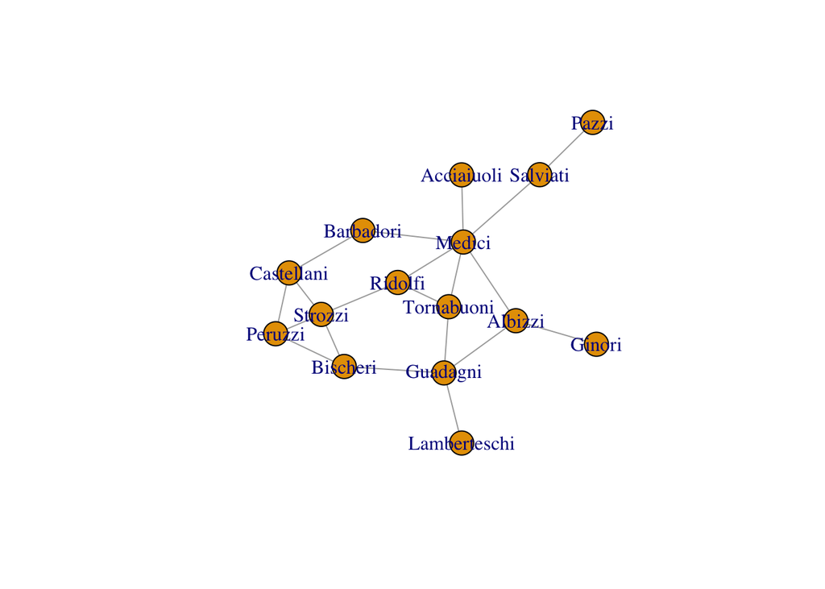

```r
## plot it
plot(marriage)
```

We can improve the visualization, changing the color of the vertices, and the labels.

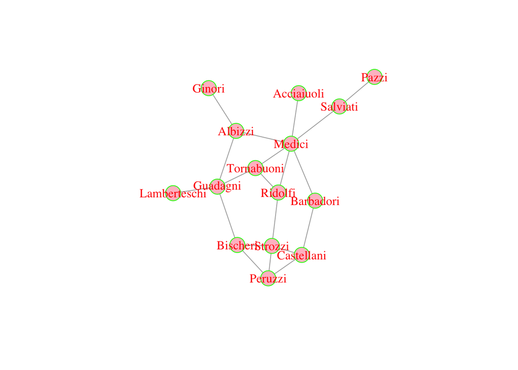

```r
## set some color atributes (V() gives back the 'vertices' = nodes)
V(marriage)$color = "pink"        # color of the nodes
V(marriage)$frame.color = "green" # color of the node frame
V(marriage)$label.color = "red"   # color of the node labels (the family names)

## plot it
plot(marriage)
```

Notice the syntax: take all the vertices in marriage (`V(marriage)`), then assign to each vertex the color pink (V(marriage)$color = “pink”). The same syntax works also for the links. Let’s change the width of the links and their color

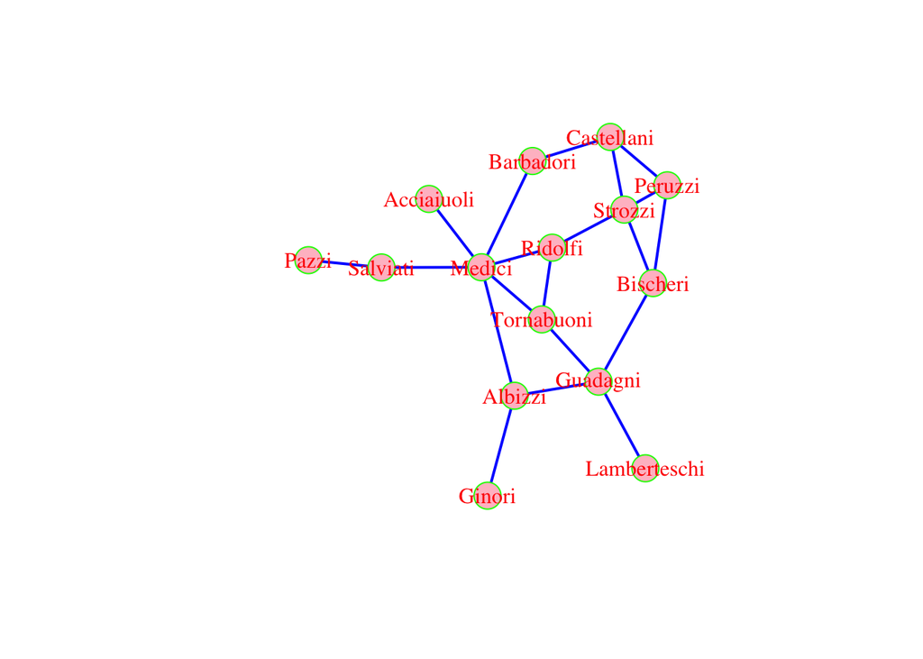

```r
## set some color atributes (E() gives back the 'edges')
E(marriage)$width <- 2        # width of edges (makes it ticker, default is 1)
E(marriage)$color <- "blue"   # color of the edges

## plot it
plot(marriage)
```

## Degree, paths, centrality

We can now compute the degree of each family and assign it to the object `deg`

```r
# computes the degree of each family
deg<-degree(marriage)
deg
```

```
##    Barbadori   Castellani      Albizzi       Ginori     Guadagni     Bischeri
##            2            3            3            1            4            3
## Lamberteschi   Acciaiuoli       Medici      Peruzzi      Ridolfi     Salviati
##            1            1            6            3            3            2
##        Pazzi      Strozzi   Tornabuoni
##            1            4            3
```

If we want to sort the families from the highest degree to the lowest, we use the command `sort`

```r
## print the degree for each family
sort(deg)                  #from lowest to highest
```

```
##       Ginori Lamberteschi   Acciaiuoli        Pazzi    Barbadori     Salviati
##            1            1            1            1            2            2
##   Castellani      Albizzi     Bischeri      Peruzzi      Ridolfi   Tornabuoni
##            3            3            3            3            3            3
##     Guadagni      Strozzi       Medici
##            4            4            6
```

```r
sort(deg, decreasing=TRUE) #from highest to lowest
```

```
##       Medici     Guadagni      Strozzi   Castellani      Albizzi     Bischeri
##            6            4            4            3            3            3
##      Peruzzi      Ridolfi   Tornabuoni    Barbadori     Salviati       Ginori
##            3            3            3            2            2            1
## Lamberteschi   Acciaiuoli        Pazzi
##            1            1            1
```

To compute the degree distribution we use

```r
# compute the degree distribution
deg.dist <- degree.distribution(marriage)
deg.dist
```

```
## [1] 0.00000000 0.26666667 0.13333333 0.40000000 0.13333333 0.00000000 0.06666667
```

Where the first number is the fraction of nodes with degree 0, the second number is the fraction of nodes with degree 1, and so on. For a visualization we can use an histogram or a dot chart

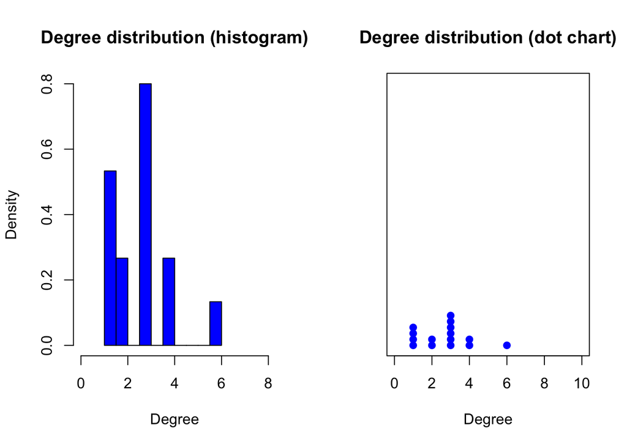

```r
# i want both plots in the same figure, so i set a parameter
# par(mfrow=c(1,2)) the command tells R to generate a figure that
# contains space for 2 graphs (in 1 row)
par(mfrow=c(1,2))
hist(deg, freq=FALSE, breaks=10, xlim=c(0,8),
     col="blue", main="Degree distribution (histogram)",
     xlab="Degree")
stripchart(deg,method="stack",at=0, xlim=c(0,10),
           pch=19, col="blue", main="Degree distribution (dot chart)",
           xlab="Degree")
```

We can also find the shortest paths between different pairs of families

```r
## calculate shortest paths
## shortest path between Peruzzi and Acciaiuoli
PtoA <- get.shortest.paths(marriage, from="Peruzzi", to="Acciaiuoli")
## shortest path between Ginori and Strozzi
GtoS <- get.shortest.paths(marriage, from="Ginori", to="Strozzi")
```

If you want ALL the shortest paths (there may be more than one), you use

```r
## all the shortest paths between Medici and Bischeri
MtoB <- get.all.shortest.paths(marriage, from="Medici", to="Bischeri")
```

The results of all these commands is an object `list`. For example the result of all shortest paths between Medici and Bischeri is a list with 3 vectors

```r
# list of results
MtoB
```

```
## $res
## $res[[1]]
## + 4/15 vertices, named, from 1f300b8:
## [1] Medici   Ridolfi  Strozzi  Bischeri
##
## $res[[2]]
## + 4/15 vertices, named, from 1f300b8:
## [1] Medici   Albizzi  Guadagni Bischeri
##
## $res[[3]]
## + 4/15 vertices, named, from 1f300b8:
## [1] Medici     Tornabuoni Guadagni   Bischeri
##
##
## $nrgeo
##  [1] 1 1 1 1 2 3 2 1 1 2 1 1 1 1 1
```

To call the first (vector) element of the `list`, i.e. the element `res[[1]]`, we use

```r
# first element of the list: a vector with the indices of families in the
# 1st shortest path between Medici and Bischeri
MtoB$res[[1]]
```

```
## + 4/15 vertices, named, from 1f300b8:
## [1] Medici   Ridolfi  Strozzi  Bischeri
```

```r
# show names of families in 2nd shortest path from Medici to Bischeri
V(marriage)[MtoB$res[[1]]]
```

```
## + 4/15 vertices, named, from 1f300b8:
## [1] Medici   Ridolfi  Strozzi  Bischeri
```

The syntax means: take the list of vertices (`V(marriage)`) and consider only the elements that are in the vector `MtoB$res[[1]]`. So it takes the subset of vertices that correspond to the ones indicated in the path `MtoB$res[[1]]`. To get the second of the shortest paths from Medici to Bischeri you type

```r
# show names of families in 2nd shortest path from Medici to Bischeri
V(marriage)[MtoB$res[[2]]]
```

```
## + 4/15 vertices, named, from 1f300b8:
## [1] Medici   Albizzi  Guadagni Bischeri
```

and the third is obtained with the same syntax.  
For the families Peruzzi and Acciaiuoli, we only asked for one of the shortest paths, so the list that we generated contains only 1 vector

```r
# list of vertices from Peruzzi (family 10) and Acciaiuoli (family 8)
PtoA
```

```
## $vpath
## $vpath[[1]]
## + 5/15 vertices, named, from 1f300b8:
## [1] Peruzzi    Castellani Barbadori  Medici     Acciaiuoli
##
##
## $epath
## NULL
##
## $predecessors
## NULL
##
## $inbound_edges
## NULL
```

As before you can always see the names associated with the path by typing (notice that now the first element of the list is just called `[[1]]`)

```r
# show names of families in path from Peruzzi to Acciaiuoli
V(marriage)[PtoA$vpath[[1]]]
```

```
## + 5/15 vertices, named, from 1f300b8:
## [1] Peruzzi    Castellani Barbadori  Medici     Acciaiuoli
```

As an exercise, do the same with the path from Ginori to Strozzi

```r
GtoS$vpath[[1]]
```

```
## + 5/15 vertices, named, from 1f300b8:
## [1] Ginori   Albizzi  Guadagni Bischeri Strozzi
```

Incidentally, notice that you can always create the same results using the vertex indicator numbers instead of the family names. For example, family Medici is number 9 in the vertex sequence and Bischeri is number 6. If you want ALL the shortest paths (there may be more than one), you use

```r
## all the shortest paths between Medici and Bischeri
MtoB <- get.all.shortest.paths(marriage, from=9, to=6)
MtoB
```

```
## $res
## $res[[1]]
## + 4/15 vertices, named, from 1f300b8:
## [1] Medici   Ridolfi  Strozzi  Bischeri
##
## $res[[2]]
## + 4/15 vertices, named, from 1f300b8:
## [1] Medici   Albizzi  Guadagni Bischeri
##
## $res[[3]]
## + 4/15 vertices, named, from 1f300b8:
## [1] Medici     Tornabuoni Guadagni   Bischeri
##
##
## $nrgeo
##  [1] 1 1 1 1 2 3 2 1 1 2 1 1 1 1 1
```

To visualize the paths we can assign each path a color (say green and blue)

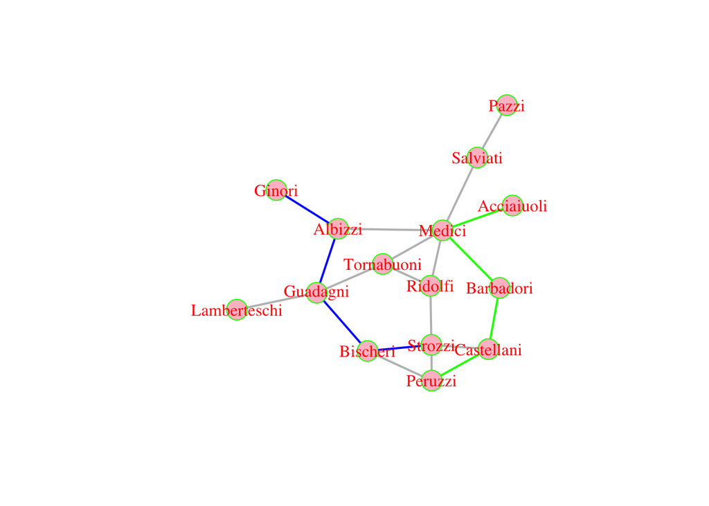

```r
## set fat edges and default grey (E() returns edges)
E(marriage)$width <- 2
E(marriage)$color <- "grey"
E(marriage, path=c(unlist(PtoA$vpath[[1]])))$color <- "green"
E(marriage, path=c(unlist(GtoS$vpath[[1]])))$color <- "blue"
plot(marriage)
```

You can also use an interactive version that will allow you to modify the layout of the plot

```
tkplot(marriage)
```

We can visualize all the shortest paths between Medici and Bischeri. The first path is obtained with the following code

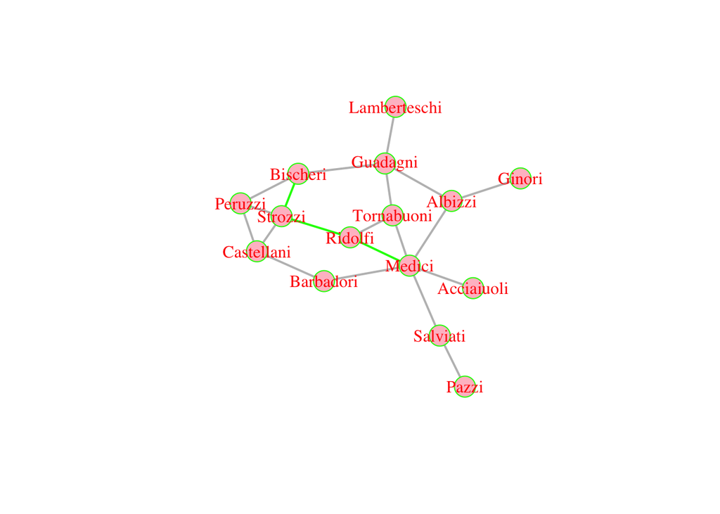

```r
## show all the shortest paths between Medici and Bischeri
E(marriage)$width <- 2          # set width of the edge to 2
E(marriage)$color <- "grey"     # sets edge color to grey
E(marriage, path=MtoB$res[[1]])$color <- "green"  # Medici=Bischeri path 1 is green
# When we draw a graph, the layout is determined by an
# algorithm, which is initialized at a random number.
# if you want all the graph to look the same, you need to set
# the seed of the random number to be the same for all graphs
# here we use 7777 but you may change the nummer
set.seed(7777)                  # sets seed for random number generator
plot(marriage)                  # plot the network
```

The second shortest path is

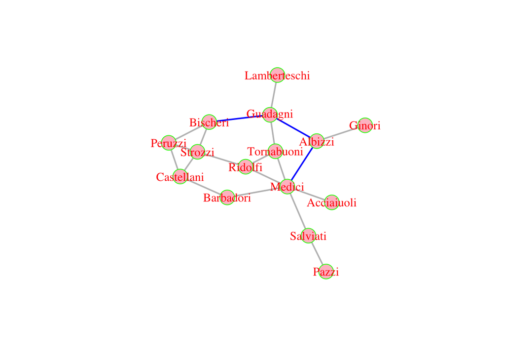

```r
# the 2nd path from Medici to Bischeri is blue
E(marriage)$color <- "grey"      # re-sets edge color to grey
E(marriage, path=MtoB$res[[2]])$color <- "blue" # Medici=Bischeri path 2 is blue
set.seed(7777)                  # sets seed for random number generator
plot(marriage)                  # plot the network
```

and the third is

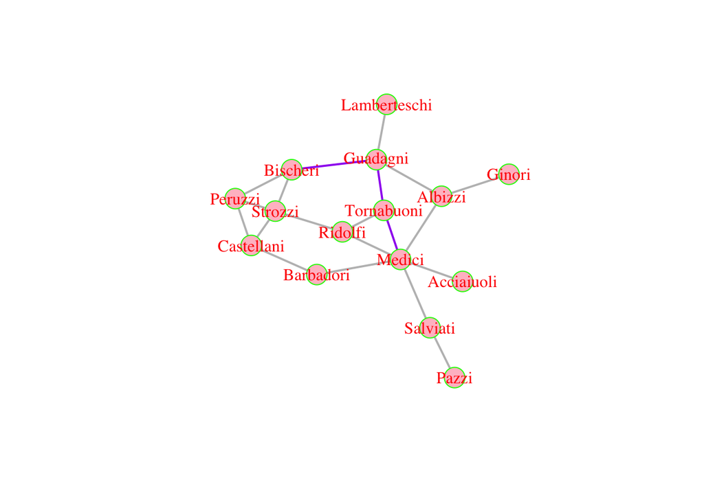

```r
# the 3rd path from Medici to Bischeri is purple
E(marriage)$color <- "grey"      # re-sets edge color to grey
E(marriage, path=MtoB$res[[3]])$color <- "purple" # Medici=Bischeri path 3 is purple
set.seed(7777)                  # sets seed for random number generator
plot(marriage)                  # plot the network
```

We can compute the **length** of the shortest paths between all families by using the command

```r
## compute the length of shortest paths among all pairs of families
shortest.paths(marriage)
```

```
##              Barbadori Castellani Albizzi Ginori Guadagni Bischeri Lamberteschi
## Barbadori            0          1       2      3        3        3            4
## Castellani           1          0       3      4        3        2            4
## Albizzi              2          3       0      1        1        2            2
## Ginori               3          4       1      0        2        3            3
## Guadagni             3          3       1      2        0        1            1
## Bischeri             3          2       2      3        1        0            2
## Lamberteschi         4          4       2      3        1        2            0
## Acciaiuoli           2          3       2      3        3        4            4
## Medici               1          2       1      2        2        3            3
## Peruzzi              2          1       3      4        2        1            3
## Ridolfi              2          2       2      3        2        2            3
## Salviati             2          3       2      3        3        4            4
## Pazzi                3          4       3      4        4        5            5
## Strozzi              2          1       3      4        2        1            3
## Tornabuoni           2          3       2      3        1        2            2
##              Acciaiuoli Medici Peruzzi Ridolfi Salviati Pazzi Strozzi
## Barbadori             2      1       2       2        2     3       2
## Castellani            3      2       1       2        3     4       1
## Albizzi               2      1       3       2        2     3       3
## Ginori                3      2       4       3        3     4       4
## Guadagni              3      2       2       2        3     4       2
## Bischeri              4      3       1       2        4     5       1
## Lamberteschi          4      3       3       3        4     5       3
## Acciaiuoli            0      1       4       2        2     3       3
## Medici                1      0       3       1        1     2       2
## Peruzzi               4      3       0       2        4     5       1
## Ridolfi               2      1       2       0        2     3       1
## Salviati              2      1       4       2        0     1       3
## Pazzi                 3      2       5       3        1     0       4
## Strozzi               3      2       1       1        3     4       0
## Tornabuoni            2      1       3       1        2     3       2
##              Tornabuoni
## Barbadori             2
## Castellani            3
## Albizzi               2
## Ginori                3
## Guadagni              1
## Bischeri              2
## Lamberteschi          2
## Acciaiuoli            2
## Medici                1
## Peruzzi               3
## Ridolfi               1
## Salviati              2
## Pazzi                 3
## Strozzi               2
## Tornabuoni            0
```

The visualization of this matrix is quite ugly in the command line. One simple solution is to save it in an external file and open it in excel to look at it (this is also a good strategy for creating tables to incorporate in your Word write-up later).  
To save a variable in an external `.csv` (comma separated value) file, we type

```r
## compute the length of shortest paths among all pairs of families
spl<-shortest.paths(marriage)
## save the resulting table into a .csv file
write.csv(spl, "spl.csv")
```

This will save a file `spl.csv` in your working folder, that contains the table. Now you can open it in excel, and format the table as you prefer and eventually copy and paste into your final write-up. (There are several packages that allow you to create tables and format them for final documents, but they require some advanced programming).

The package contains several functions to compute the centrality measures. Let’s start from the simplest centrality index, the **degree centrality**. We already computed the degree of each family, so we just need to normalize this measure by the number of nodes in the network

```r
# how many nodes in the network?
n <- length(V(marriage))
# degree centrality = degree/(n-1)
deg.cent <-  deg/(n-1)
```

The betweenness centrality index is computed using the command

```r
## compute the betweenness for each family
bet<-betweenness(marriage)
```

Notice that the function `betweenness` provides a value that is not normalized (the formula we used in class was normalized). To obtain the same values we saw in class you need to divide the value by `n*(n-1)/2` (be careful with the parentheses)

```r
## compute the betweenness centrality index for each family
bet.cent<-bet/(n*(n-1)/2)
```

To compute the closeness centrality we use the command `closeness` (no need to normalize the results here)

```r
close.cent <- closeness(marriage)
```

Finally we can compute the eigenvector centrality index using the function `evcent`

```r
# compute eigenvector centrality
eig.cent <- evcent(marriage, directed=FALSE)$vector
```

and page-rank

```r
# compute page rank
pr.cent <- page.rank(marriage, directed=FALSE)$vector
```

Both eigenvector centrality and pagerank are examples of neighbor centrality indices.  
If you don’t like the many decimal places, you can always change that by using the function `round`. If you want 2 decimal places,

```r
round(pr.cent, 2)
```

```
##    Barbadori   Castellani      Albizzi       Ginori     Guadagni     Bischeri
##         0.05         0.07         0.08         0.03         0.10         0.07
## Lamberteschi   Acciaiuoli       Medici      Peruzzi      Ridolfi     Salviati
##         0.03         0.03         0.15         0.07         0.07         0.06
##        Pazzi      Strozzi   Tornabuoni
##         0.04         0.09         0.07
```

Finally let’s consider the triadic closure property and the clustering coefficient. In our software, the clustering coefficient is called `transitivity`

```r
## clustering coefficient for each family
clust <- transitivity(marriage, type="local")
```

Notice that for some family, the result is `NaN`, i.e. `Not a Number`. Why do you think this is?

The last thing we will do with these indices, is to create a data.frame with all of them, to be eventually used in a statistical analysis

```r
indices <- data.frame(clust, deg.cent, bet.cent, close.cent, eig.cent, pr.cent)
indices
```

```
##                   clust   deg.cent   bet.cent close.cent  eig.cent    pr.cent
## Barbadori    0.00000000 0.14285714 0.08095238 0.03125000 0.4919853 0.05030099
## Castellani   0.33333333 0.21428571 0.04761905 0.02777778 0.6019551 0.06933018
## Albizzi      0.00000000 0.21428571 0.18412698 0.03448276 0.5669336 0.07912225
## Ginori              NaN 0.07142857 0.00000000 0.02380952 0.1741141 0.03241797
## Guadagni     0.00000000 0.28571429 0.22063492 0.03333333 0.6718805 0.09839783
## Bischeri     0.33333333 0.21428571 0.09047619 0.02857143 0.6572037 0.06886180
## Lamberteschi        NaN 0.07142857 0.00000000 0.02325581 0.2063449 0.03090954
## Acciaiuoli          NaN 0.07142857 0.00000000 0.02631579 0.3071155 0.03065744
## Medici       0.06666667 0.42857143 0.45238095 0.04000000 1.0000000 0.14581720
## Peruzzi      0.66666667 0.21428571 0.01904762 0.02631579 0.6407743 0.06787531
## Ridolfi      0.33333333 0.21428571 0.09841270 0.03571429 0.7937398 0.06957427
## Salviati     0.00000000 0.14285714 0.12380952 0.02777778 0.3390994 0.06130323
## Pazzi               NaN 0.07142857 0.00000000 0.02040816 0.1041427 0.03605387
## Strozzi      0.33333333 0.28571429 0.08888889 0.03125000 0.8272688 0.08809844
## Tornabuoni   0.33333333 0.21428571 0.07936508 0.03448276 0.7572302 0.07127969
```

To understand that all these indices measure centrality based on different definitions, we can plot all of them and see

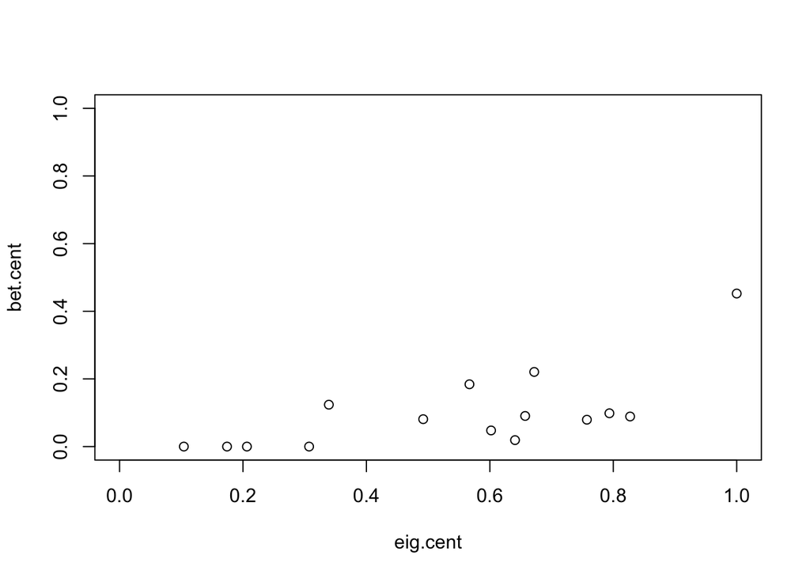

```r
# plot eigenvector vs betweeness centrality
plot(eig.cent, bet.cent, xlim=c(0,1), ylim=c(0,1))
```

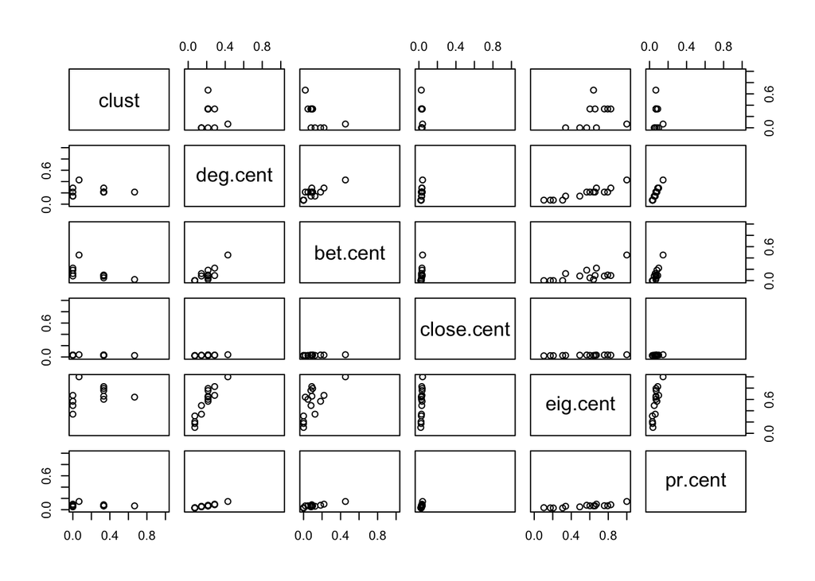

```r
# plot all pair of indices
pairs(indices, xlim=c(0,1), ylim=c(0,1))
```

```r
# compute correlations among indices
cor(indices)
```

```
##            clust  deg.cent  bet.cent close.cent  eig.cent   pr.cent
## clust          1        NA        NA         NA        NA        NA
## deg.cent      NA 1.0000000 0.8441513  0.8245138 0.9253685 0.9857596
## bet.cent      NA 0.8441513 1.0000000  0.8066296 0.6654795 0.9132374
## close.cent    NA 0.8245138 0.8066296  1.0000000 0.8681187 0.8247800
## eig.cent      NA 0.9253685 0.6654795  0.8681187 1.0000000 0.8645547
## pr.cent       NA 0.9857596 0.9132374  0.8247800 0.8645547 1.0000000
```

You can see that they are all highly correlated,of course. For clustering, the software does not compute the correlation (output is `NA`, i.e not available), because some values of clustering are not numbers. As an exercise, change those values to 0, and then repeat the computation of correlations.

## A measure of Structural holes

The package contains a measure of structural holes, the constraint. This is the measure used by Burt, to measure brokerage opportunities

```r
## compute constraint (structural hole)
constr <- constraint(marriage)
constr
```

```
##    Barbadori   Castellani      Albizzi       Ginori     Guadagni     Bischeri
##    0.5000000    0.4822531    0.3333333    1.0000000    0.2500000    0.4822531
## Lamberteschi   Acciaiuoli       Medici      Peruzzi      Ridolfi     Salviati
##    1.0000000    1.0000000    0.2098765    0.6558642    0.4598765    0.5000000
##        Pazzi      Strozzi   Tornabuoni
##    1.0000000    0.4583333    0.4598765
```

This command gives a vector of indicators, one for each family.

## Network data with additional node variables

Sometimes you will have data on the network connections, but also data on the individual characteristics of the nodes. Let’s look at the data contained in the two files: `edgelist.txt` and `attr.txt`. The fist contains a list of all the edges in the network, the second contains for each individual in the network 2 variables: sex and race. In total we have 256 individuals in this network, and 257 links in total.  
Sex is equal to 1 if male, and 2 if female. Race is equal to 1 if white/caucasian, and 2 if black/african american. A link represents a sexual relationship between the nodes involved.

```r
# load list of edges in memory
el <- read.table("edgelist.txt")
# load individual attributes in memory
attr <- read.table("attr.txt", header=TRUE)
```

We will now create the network object so that we can plot it and do the analysis.

```r
g <- graph.edgelist(as.matrix(el), directed=FALSE)
g
```

```
## IGRAPH 7b37759 U--- 256 257 --
## + edges from 7b37759:
##  [1]   3--166  33--153  39--210  49--193  74--165  87--212 105--228 107--234
##  [9] 111--216 126--247  71--157 122--188 103--238 107--246  51--234  69--157
## [17]  71--165  69--191 125--225 105--249 117--234   3--139   5--194  24--137
## [25] 107--228  65--157  45--169  21--166 132--246   3--146  21--152  52--212
## [33] 102--240  74--208  60--152 123--246  87--164 132--248  50--191 111--247
## [41]  69--190  51--203  74--162 108--234 120--244 112--157  60--192  30--165
## [49]  12--188  78--166 122--245  53--230  17--176  53--152  26--164 125--248
## [57]  71--138  65--180  78--156  69--178   4--208  31--190  40--167  25--193
## [65] 121--255  71--151  33--152  49--146 122--254 108--220 106--234  70--176
## + ... omitted several edges
```

Notice that this graph does not have any attributes. Now we will attach sex and race to each node.

```r
V(g)$sex <- attr$sex
```

If you now check the network object

```r
g
```

```
## IGRAPH 7b37759 U--- 256 257 --
## + attr: sex (v/n)
## + edges from 7b37759:
##  [1]   3--166  33--153  39--210  49--193  74--165  87--212 105--228 107--234
##  [9] 111--216 126--247  71--157 122--188 103--238 107--246  51--234  69--157
## [17]  71--165  69--191 125--225 105--249 117--234   3--139   5--194  24--137
## [25] 107--228  65--157  45--169  21--166 132--246   3--146  21--152  52--212
## [33] 102--240  74--208  60--152 123--246  87--164 132--248  50--191 111--247
## [41]  69--190  51--203  74--162 108--234 120--244 112--157  60--192  30--165
## [49]  12--188  78--166 122--245  53--230  17--176  53--152  26--164 125--248
## [57]  71--138  65--180  78--156  69--178   4--208  31--190  40--167  25--193
## + ... omitted several edges
```

we observe that there is an attribute attached to the vertices, i.e. sex. Attaching the race is similar

```r
V(g)$race <-attr$race
```

and now the network contains 2 attributes

```r
g
```

```
## IGRAPH 7b37759 U--- 256 257 --
## + attr: sex (v/n), race (v/n)
## + edges from 7b37759:
##  [1]   3--166  33--153  39--210  49--193  74--165  87--212 105--228 107--234
##  [9] 111--216 126--247  71--157 122--188 103--238 107--246  51--234  69--157
## [17]  71--165  69--191 125--225 105--249 117--234   3--139   5--194  24--137
## [25] 107--228  65--157  45--169  21--166 132--246   3--146  21--152  52--212
## [33] 102--240  74--208  60--152 123--246  87--164 132--248  50--191 111--247
## [41]  69--190  51--203  74--162 108--234 120--244 112--157  60--192  30--165
## [49]  12--188  78--166 122--245  53--230  17--176  53--152  26--164 125--248
## [57]  71--138  65--180  78--156  69--178   4--208  31--190  40--167  25--193
## + ... omitted several edges
```

Let’s make a plot of the network, where we highlight the gender using colors. Let’s use blue for males and red for females

```r
par(mfrow=c(1,1))
vcol <- rep("red", 256)
vcol[attr$sex == 1] <- "blue"
V(g)$color <- vcol
```

We can also change other parmeters directly in the `plot` command. Let’s change the size of the nodes (`vertex.size=7`), the color of the nodes labels (`vertex.label.color="white"`), and rescale the label size to 60% (`vertex.label.cex=0.6`), increase the width of the edges (`edge.width= 2`) and the color of the edges (`edge.color = "black"`, default is usually gray)

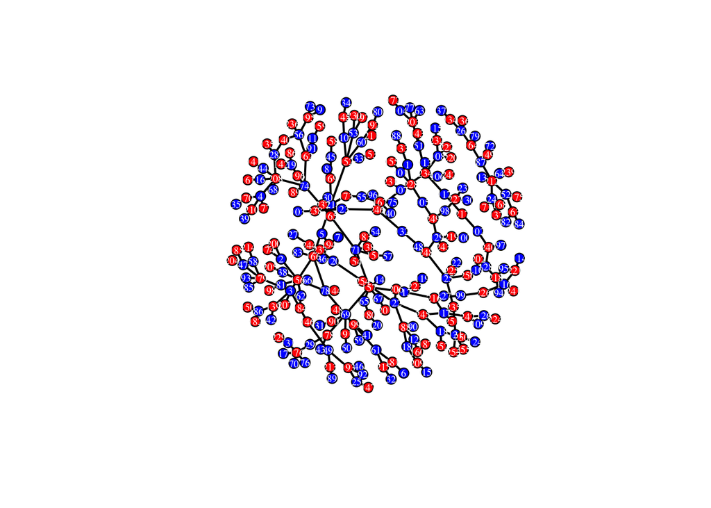

```r
plot(g, vertex.size=7, vertex.label.color="white", vertex.label.cex=0.6, edge.width= 2, edge.color = "black" )
```

You can save this image for your write up in two ways. One is manually clicking on “Export” in RStudio plot window, and selecting the format. The second is by writing the following simple code (let’s say you want to save the picture in `.png` format)

```r
png("Figure1.png")    # choses the file to save the picture
plot(g, vertex.size=7, vertex.label.color="white", vertex.label.cex=0.6, edge.width= 2, edge.color = "black" )   # produces the figure
dev.off()   # closes the file
```

If you now open your working folder, you should find a new file with `png` extension, which contains the graph plot. There are many other formats (JPEG, TIFF, PS, etc). for example, to save the picture in pdf format you type

```r
pdf("Figure1.pdf")    # choses the file to save the picture
plot(g, vertex.size=7, vertex.label.color="white", vertex.label.cex=0.6, edge.width= 2, edge.color = "black" )   # produces the figure
dev.off()   # closes the file
```

Let’s now make another picture where we highlight the racial group using colors: we will have the Caucasians represented in `green` and the African Americans in `orange`.

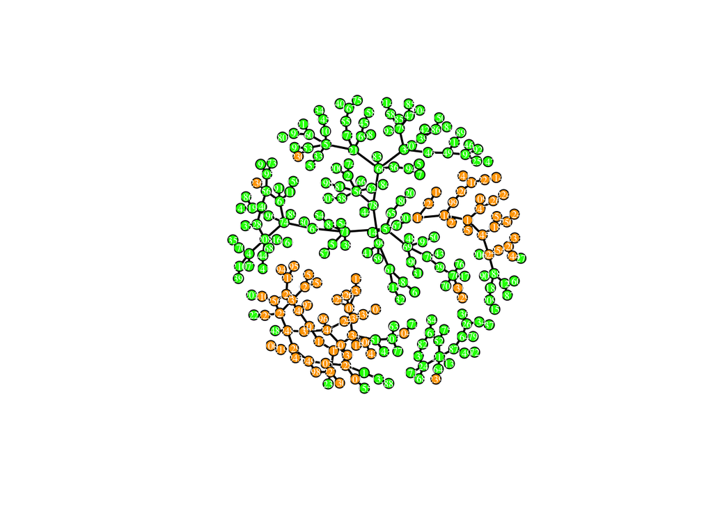

```r
par(mfrow=c(1,1))
vcol <- rep("green", 256)
vcol[attr$race == 2] <- "orange"
V(g)$color <- vcol
plot(g, vertex.size=7, vertex.label.color="white", vertex.label.cex=0.6, edge.width= 2, edge.color = "black" )   # produces the figure
```

How about visualizing the race and gender contemporaneously in the same graph? We could use the colors for race and the shape of the nodes to indicate gender. We will use circles for females and squares for males.

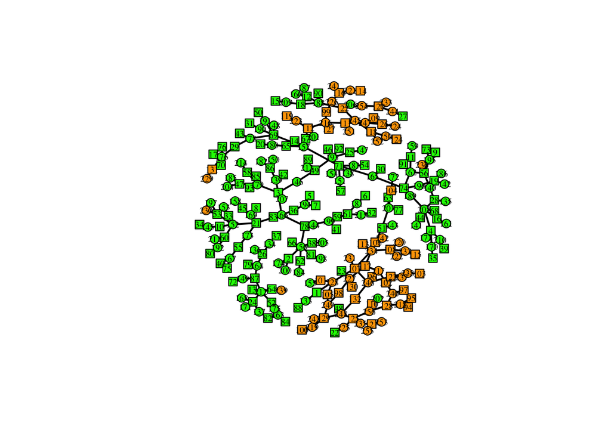

```r
par(mfrow=c(1,1))
vshape <- rep("circle", 256)
vshape[attr$sex == 1] <- "square"
plot(g, vertex.size=7, vertex.label.color="black", vertex.label.cex=0.6, edge.width= 2, edge.color = "black", vertex.shape=vshape )   # produces the figure
```

We can now compute all of the network measures we discussed before. And add those to the data we already have on race and gender, to perform additional analyses, e.g. regression analysis.

## Community structure

Social networks usually organize in communities. Discovering these commmunities is sometimes hard, especially when we only observe the link among individuals and have no additional information on them.

```r
comm_struct <- fastgreedy.community(g)
```

To check how many communities we have

```r
length(comm_struct)
```

```
## [1] 15
```

and to see the size of each community

```r
sizes(comm_struct)
```

```
## Community sizes
##  1  2  3  4  5  6  7  8  9 10 11 12 13 14 15
## 23 24 22 22 22 16 16 18 15 24 12 12 11 11  8
```

We can also display the community of each individual

```r
membership(comm_struct)
```

```
##   [1] 10 14  2 11  6  6  6  1 12  1 12 15  4  3 15 11  3 15  9  3  1  5  5  4  2
##  [26]  4  8 12  3  9  3  6  1  1 11  6  4 14 11  1  6  2  3 11  1  2  2 10  2  3
##  [51]  7  4  1  9  1 12  9  2  6  1  6 14  7  4  3 14  3 11  3  3  9  4 12  9  1
##  [76]  3  7  6  4  1 14  4  6  4  2  2  4 10  2 15 12  2  2  5  5 10  5 10 13 10
## [101] 10  5 10  7 10  7 10  7  8  5  8 13  7 13  7 13  5  8 13  8  5  8 10  8  5
## [126]  8 13  5 10  5  3 10 10  4 12  4  4  9  2 12 11  9  7  6  1  2  2  3  4  2
## [151]  9  1  1  9 10 14  3  1 12 15 11 12  4  4  9  6  1  4  1 11  4  7  1 14  4
## [176]  3 11  3  2  3  6  2  9 14  2  9 15 15  9  3  3  1  2  6 12  9  1 14  6 14
## [201]  3  5  7  2 14  8  2 11 15 11  1  4  2  2  6 13  5  5 10  7 13  7 13  8  5
## [226] 13  5 10  3  1 10  7  8  7  5 12 10 10  4  5 13  7 10  8  8 10  8 10 10  8
## [251]  8  8  5  8  5  5
```

We can also plot

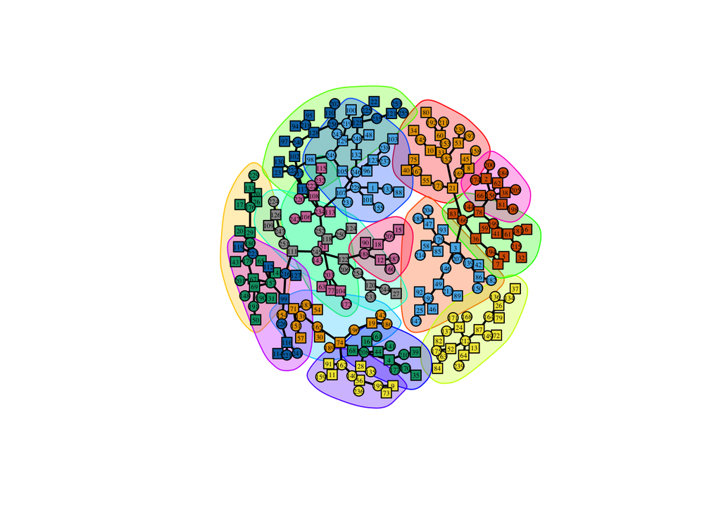

```r
plot(comm_struct,g, vertex.size=7, vertex.label.color="black", vertex.label.cex=0.4, edge.width= 2, edge.color = "black", vertex.shape=vshape )   # produces the figure
```